# LAB OF INFORMATION SYSTEMS AND ANALYTICS- PROJECT

Given the dominance of 'Avg Rentals 7days' and 'Hour' in the feature importance plot, it's clear that some features have minimal impact on predicting 'Rented Bike Count'. To refine feature selection and enhance model performance, I decided to apply Recursive Feature Elimination (RFE) to systematically identify and rank the most critical features.

```
Selected features by RFECV: ['Hour', 'Temperature(°C)', 'Winter', 'Total Rentals Month', 'Expanding Avg Temperature', 'Expanding Avg Rentals', 'Avg Temperature 7days', 'Avg Rentals 7days', 'Evening', 'Night']
```

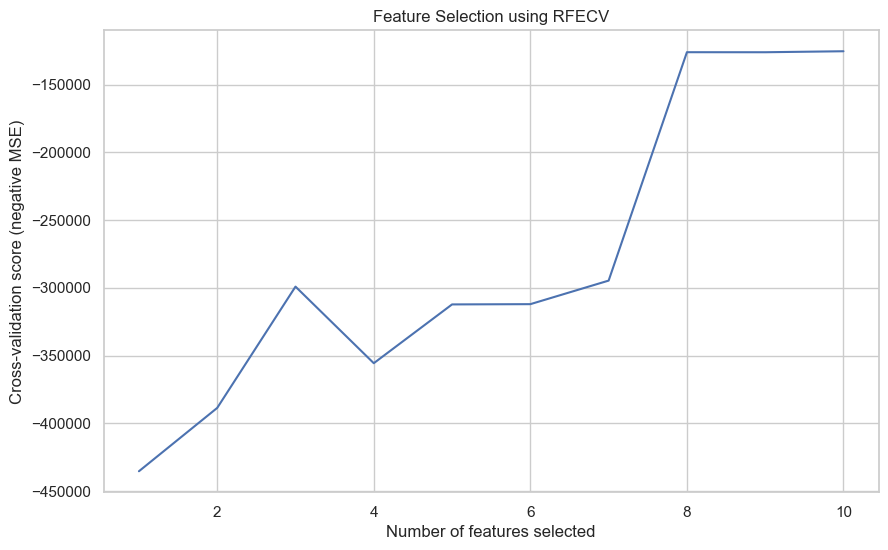

```python
# Define the model
model = LinearRegression()

# Initialize RFECV
rfecv = RFECV(estimator=model, step=1, cv=5, scoring='neg_mean_squared_error')
# Fit RFECV to the data
rfecv.fit(X, y)

# Create a DataFrame to store feature rankings
feature_ranking = pd.DataFrame({
    'Feature': X.columns,
    'Ranking': rfecv.ranking_,
    'Support': rfecv.support_
})

# Select the features marked as important
selected_features = feature_ranking[feature_ranking['Support']]['Feature'].tolist()

print("Selected features by RFECV:", selected_features)

# Plot number of features vs cross-validation scores
plt.figure(figsize=(10, 6))
plt.xlabel("Number of features selected")
plt.ylabel("Cross-validation score (negative MSE)")
plt.title("Feature Selection using RFECV")

# Using cv_results_['mean_test_score'] to plot the scores
plt.plot(range(1, len(rfecv.cv_results_['mean_test_score']) + 1), rfecv.cv_results_['mean_test_score'])
plt.show()
```

```python
# Define the features to scale
features_to_scale = [
    'Temperature(°C)',
    'Expanding Avg Temperature',
    'Expanding Avg Rentals',
    'Avg Temperature 7days',
    'Avg Rentals 7days',
    'Total Rentals Month'
]

# Initialize the scaler
scaler = StandardScaler()

# Fit and transform the scaler on the selected features
bike_data[features_to_scale] = scaler.fit_transform(bike_data[features_to_scale])

# Check the scaled data
print(bike_data[features_to_scale].head())
```

```
   Temperature(°C)  Expanding Avg Temperature  Expanding Avg Rentals  \
0        -1.513957                  -1.666591              -1.165300
1        -1.539074                  -1.690258              -1.297698
2        -1.580936                  -1.724444              -1.396556
3        -1.597680                  -1.749426              -1.533368
4        -1.580936                  -1.758104              -1.646172

   Avg Temperature 7days  Avg Rentals 7days  Total Rentals Month
0              -1.526850          -0.812931            -1.386853
1              -1.539517          -0.858052            -1.386853
2              -1.557815          -0.891742            -1.386853
3              -1.571186          -0.938366            -1.386853
4              -1.575831          -0.976809            -1.386853
```

Here I decided to scale again the selected features before training the model. I initially split the dataset into 80% training and 20% testing sets. Subsequently, the training set was further split into 75% for training and 25% for validation, creating a final training set and a validation set.

```python
# Define features and target variable
X = bike_data[selected_features]
y = bike_data['Rented Bike Count']

# Initial split - 80% training, 20% testing
X_train_full, X_test, y_train_full, y_test = train_test_split(X, y, test_size=0.2, random_state=42)

# Display the shape of the resulting datasets
print(f"Initial training data shape: {X_train_full.shape}, Testing data shape: {X_test.shape}")
```

```
Initial training data shape: (7008, 10), Testing data shape: (1752, 10)
```

```python
# Further split training data into 75% training, 25% validation
X_train, X_val, y_train, y_val = train_test_split(X_train_full, y_train_full, test_size=0.25, random_state=42)

# Display the shape of the resulting datasets
print(f"Final training data shape: {X_train.shape}, Validation data shape: {X_val.shape}")
```

```
Final training data shape: (5256, 10), Validation data shape: (1752, 10)
```

```python
# Initialize the Random Forest model
rf_model = RandomForestRegressor(random_state=42)

# Train the model on the training set
rf_model.fit(X_train, y_train)

# Predict on the validation set
val_predictions = rf_model.predict(X_val)

# Evaluate on the validation set
val_rmse = np.sqrt(mean_squared_error(y_val, val_predictions))
val_mae = mean_absolute_error(y_val, val_predictions)
val_r2 = r2_score(y_val, val_predictions)

# Print validation metrics
print(f"Validation RMSE: {val_rmse}")
print(f"Validation MAE: {val_mae}")
print(f"Validation R²: {val_r2}")

# Step 3: Final evaluation on the test set
test_predictions = rf_model.predict(X_test)

# Evaluate on the test set
test_rmse = np.sqrt(mean_squared_error(y_test, test_predictions))
test_mae = mean_absolute_error(y_test, test_predictions)
test_r2 = r2_score(y_test, test_predictions)

# Print test metrics
print(f"Test RMSE: {test_rmse}")
print(f"Test MAE: {test_mae}")
print(f"Test R²: {test_r2}")
```

```
Validation RMSE: 166.59858848301195
Validation MAE: 95.08465182648402
Validation R²: 0.931798491639769
Test RMSE: 165.92829208576129
Test MAE: 97.8544292237443
Test R²: 0.9339194846305937
```

The output shows that the Random Forest model has a good fit on the validation and test sets, with the following metrics:

- **Validation Metrics:** RMSE of 166.6, MAE of 95.1, and R² of 0.9318. These values suggest the model is performing well on the validation set with a strong fit and high predictive accuracy.
- **Test Metrics:** RMSE of 165.9, MAE of 97.9, and R² of 0.9339. These results are consistent with the validation performance, showing that the model generalizes well to new data.

```python
# Models to evaluate
models = {
    'Random Forest': RandomForestRegressor(random_state=42),
    'Gradient Boosting': GradientBoostingRegressor(random_state=42),
    'Linear Regression': LinearRegression(),
    'Support Vector Regressor': SVR(),
    'Neural Network': MLPRegressor(random_state=42, max_iter=1000, learning_rate_init=0.001, early_stopping=True, n_iter_no_change=10)
}

# Dictionary to store the results
results = {}

for name, model in models.items():
    # Fit the model on the training data
    model.fit(X_train, y_train)

    # Predict on the validation data
    val_predictions = model.predict(X_val)

    # Calculate validation metrics
    val_rmse = np.sqrt(mean_squared_error(y_val, val_predictions))
    val_mae = mean_absolute_error(y_val, val_predictions)
    val_r2 = r2_score(y_val, val_predictions)

    # Store the results
    results[name] = {
        'Validation RMSE': val_rmse,
        'Validation MAE': val_mae,
        'Validation R2': val_r2
    }

# Display results
for model_name, metrics in results.items():
    print(f"{model_name} – Validation RMSE: {metrics['Validation RMSE']:.2f}, "
          f"Validation MAE: {metrics['Validation MAE']:.2f}, Validation R2: {metrics['Validation R2']:.4f}")

# Choose the best model based on Validation R2
best_model_name = max(results, key=lambda x: results[x]['Validation R2'])
best_model = models[best_model_name]

# Retrain the best model on the full training data and evaluate on the test set
best_model.fit(X_train_full, y_train_full)
test_predictions = best_model.predict(X_test)

# Test metrics
test_rmse = np.sqrt(mean_squared_error(y_test, test_predictions))
test_mae = mean_absolute_error(y_test, test_predictions)
test_r2 = r2_score(y_test, test_predictions)

print(f"\nBest Model: {best_model_name}")
print(f"Test RMSE: {test_rmse:.2f}, Test MAE: {test_mae:.2f}, Test R2: {test_r2:.4f}")
```

```
Random Forest – Validation RMSE: 166.60, Validation MAE: 95.08, Validation R2: 0.9318
Gradient Boosting – Validation RMSE: 198.41, Validation MAE: 131.86, Validation R2: 0.9033
Linear Regression – Validation RMSE: 328.34, Validation MAE: 250.40, Validation R2: 0.7351
Support Vector Regressor – Validation RMSE: 541.80, Validation MAE: 389.17, Validation R2: 0.2787
Neural Network – Validation RMSE: 281.24, Validation MAE: 187.87, Validation R2: 0.8056

Best Model: Random Forest
Test RMSE: 161.00, Test MAE: 93.52, Test R2: 0.9378
```

The output indicates that the Random Forest model performs best among the evaluated models, with the lowest validation RMSE (166.60) and highest R² (0.9318). The model generalizes well to new data, as shown by the test metrics: RMSE of 161.00, MAE of 93.52, and R² of 0.9378. This suggests that the Random Forest model is a strong predictor for my dataset.

```python
# Define the parameter grid for hyperparameter tuning
param_grid = {
    'n_estimators': [100, 200, 300],
    'max_depth': [None, 10, 20, 30],
    'min_samples_split': [2, 5, 10],
    'min_samples_leaf': [1, 2, 4],
    'bootstrap': [True, False]
}

# Initialize the Random Forest model
rf = RandomForestRegressor(random_state=42)

# Set up the Grid Search with Cross-Validation
grid_search = GridSearchCV(estimator=rf, param_grid=param_grid,
                           cv=5, n_jobs=-1, verbose=2, scoring='neg_mean_squared_error')

# Fit the model on the training data
grid_search.fit(X_train_full, y_train_full)

# Best parameters and model performance
best_params = grid_search.best_params_
best_model = grid_search.best_estimator_

# Predict on the test set with the best model
test_predictions = best_model.predict(X_test)

# Evaluate the test set with the best model
test_rmse = np.sqrt(mean_squared_error(y_test, test_predictions))
test_mae = mean_absolute_error(y_test, test_predictions)
test_r2 = r2_score(y_test, test_predictions)

print(f"Best Parameters: {best_params}")
print(f"Test RMSE: {test_rmse:.2f}, Test MAE: {test_mae:.2f}, Test R2: {test_r2:.4f}")
```

```
Fitting 5 folds for each of 216 candidates, totalling 1080 fits
Best Parameters: {'bootstrap': True, 'max_depth': 30, 'min_samples_leaf': 1, 'min_samples_split': 2, 'n_estimators': 300}
Test RMSE: 158.95, Test MAE: 92.64, Test R2: 0.9394
```

The **Grid Search** is exploring 216 combinations of hyperparameters using 5-fold cross-validation, totaling 1080 fits. The output shows the results of hyperparameter tuning for the Random Forest model after Cross-Validation. The code generated a Test RMSE of 158.95, Test MAE of 92.64, and Test R² of 0.9394. This indicates that the tuned model has improved predictive accuracy and explains about 93.94% of the variance in the target variable on the test data.

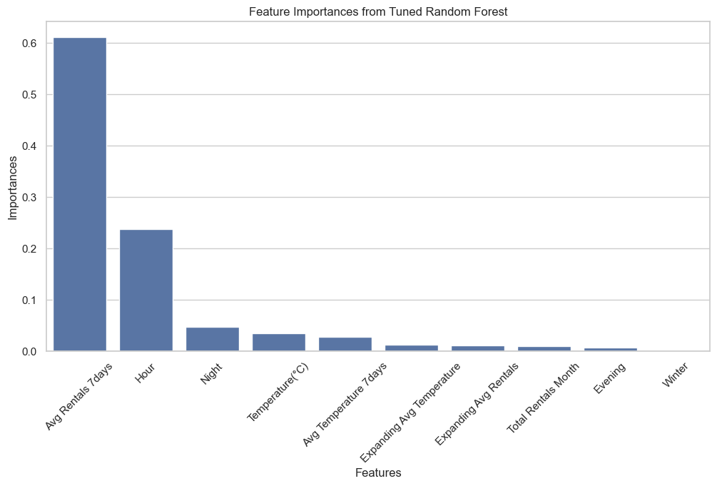

```python
# Plot the feature importances from the best model
importances = best_model.feature_importances_
features = X_train_full.columns
feature_importances = pd.DataFrame(importances, index=features, columns=['Importances']).sort_values(by='Importances', ascending=False)

# Plotting feature importances
plt.figure(figsize=(12, 6))
sns.barplot(x=feature_importances.index, y=feature_importances['Importances'])
plt.xticks(rotation=45)
plt.title('Feature Importances from Tuned Random Forest')
plt.xlabel('Features')
plt.ylabel('Importances')
plt.show()
```

After tuning the Random Forest model, I ran the feature importance plot again to verify any changes in feature rankings due to hyperparameter adjustments. Notably, the Temperature feature has moved one position up compared to the initial plot, indicating its increased importance in the tuned model. This shift highlights how tuning have an impact in the model's perception of feature relevance.

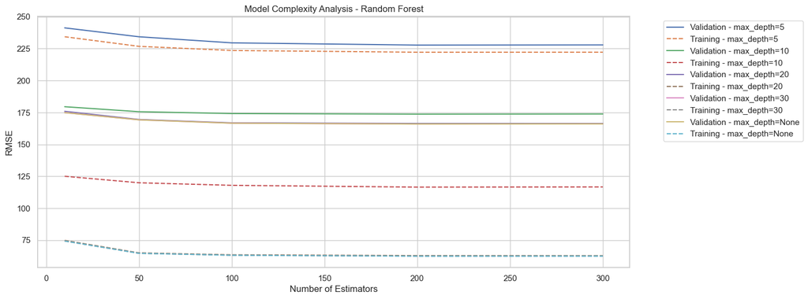

```python
# Lists to store results
train_errors = []
val_errors = []
n_estimators_range = [10, 50, 100, 200, 300]
max_depth_range = [5, 10, 20, 30, None]

# Iterate over different values of n_estimators and max_depth
for n_estimators in n_estimators_range:
    for max_depth in max_depth_range:
        # Initialize and fit the model with current hyperparameters
        model = RandomForestRegressor(n_estimators=n_estimators, max_depth=max_depth, random_state=42)
        model.fit(X_train, y_train)

        # Predict on training set and validation set
        train_pred = model.predict(X_train)
        val_pred = model.predict(X_val)

        # Calculate RMSE for training and validation sets
        train_rmse = np.sqrt(mean_squared_error(y_train, train_pred))
        val_rmse = np.sqrt(mean_squared_error(y_val, val_pred))

        # Store the results
        train_errors.append((n_estimators, max_depth, train_rmse))
        val_errors.append((n_estimators, max_depth, val_rmse))

# Convert results to a more convenient format for plotting
train_errors = np.array(train_errors)
val_errors = np.array(val_errors)

# Plotting Model Complexity Analysis
plt.figure(figsize=(14, 6))

# Plot RMSE against number of estimators for different depths
for max_depth in max_depth_range:
    plt.plot(n_estimators_range, val_errors[val_errors[:, 1] == max_depth][:, 2], label=f'Validation - max_depth={max_depth}')
    plt.plot(n_estimators_range, train_errors[train_errors[:, 1] == max_depth][:, 2], linestyle='--', label=f'Training - max_depth={max_depth}')

plt.xlabel('Number of Estimators')
plt.ylabel('RMSE')
plt.title('Model Complexity Analysis - Random Forest')
plt.legend(bbox_to_anchor=(1.05, 1), loc='upper left')
plt.grid(True)
plt.show()
```

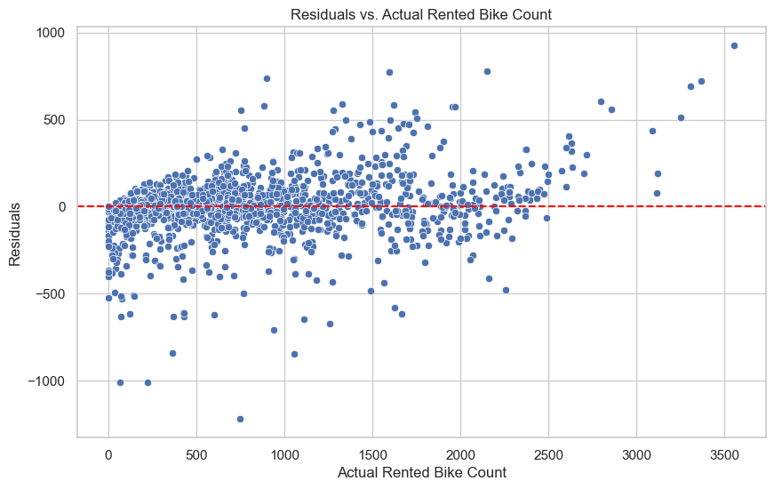

```python
# Calculate residuals
residuals = y_test - test_predictions

# Plot residuals
plt.figure(figsize=(10, 6))
sns.scatterplot(x=y_test, y=residuals)
plt.axhline(0, linestyle='--', color='red')
plt.title('Residuals vs. Actual Rented Bike Count')
plt.xlabel('Actual Rented Bike Count')
plt.ylabel('Residuals')
plt.show()
```

The **residual plot** shows the difference between the actual rented bike counts and the model's predictions. The residuals are centered around zero, which is a good sign, indicating that the model does not have significant bias. However, the spread of residuals increases as the actual bike counts increase, suggesting that the model may struggle with higher counts, showing some heteroscedasticity (unequal variance). This pattern indicates the model's predictive accuracy is not consistent across all ranges of bike rentals, with larger errors occurring for higher counts.

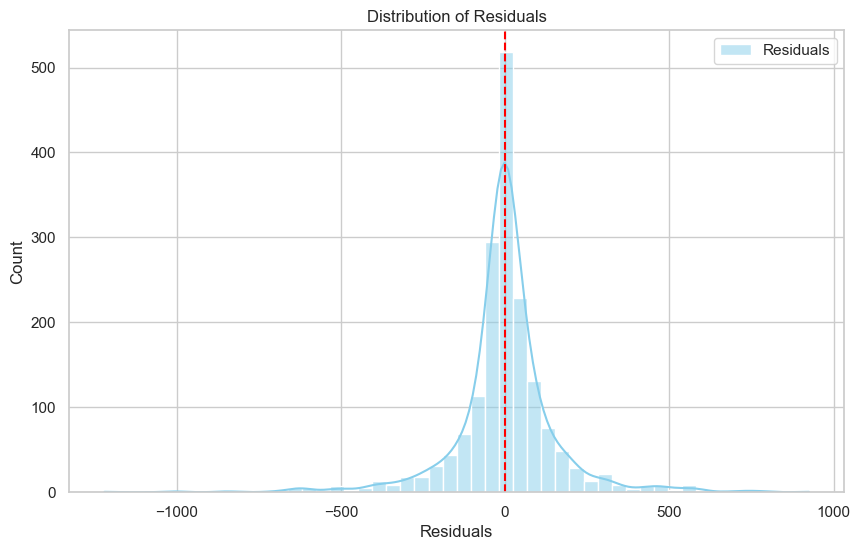

```python
# Plotting the distribution of residuals
plt.figure(figsize=(10, 6))
sns.histplot(residuals, kde=True, bins=50, color='skyblue', label='Residuals')
plt.axvline(x=0, color='red', linestyle='--')
plt.title('Distribution of Residuals')
plt.xlabel('Residuals')
plt.ylabel('Count')
plt.legend()
plt.show()
```

The **histogram** of the residuals shows that they are centered around zero, which is expected for a well-fitted model. However, the distribution appears slightly skewed with tails extending further to the left and right, indicating that there are some larger residuals on both ends. This suggests that while the model generally performs well, there are still some instances where it significantly over or under-predicts the target variable.

In the feature inspection phase, I handled the 'Date' column initially converted to a datetime format to extract valuable temporal features such as 'Year', 'Month', and 'Day', before dropping the original 'Date' column to streamline the dataset. Features like 'Rainfall' and 'Snowfall' were removed due to their inconsistent distributions, with values predominantly at zero, indicating minimal impact on the target variable. This decision was supported by their low correlations with bike rentals, which suggested that these features added noise rather than predictive power.

Then I focused on the most skewed features to reduce the number of outliers, which could potentially impact model performance. Logarithmic transformations were applied to features such as 'Wind speed (m/s)' and 'Solar Radiation (MJ/m2)' to normalize their distributions.

To address multicollinearity, features like 'Temperature(°C)' and 'Dew Point Temperature(°C)' were carefully evaluated, resulting in the removal of the latter to maintain model simplicity and prevent overfitting.

The choices made in feature engineering were to create several new features to enhance the models' predictive capabilities. These included temporal features such as 'Avg Rentals 7days', 'Avg Temperature 7days', and 'Total Rentals Month', which provided insights into weekly trends. Additional expanding features like 'Expanding Total Rentals', 'Expanding Avg Temperature', and 'Expanding Avg Rentals' helped capture cumulative patterns over time. Moreover, categorical features 'Afternoon', 'Evening', 'Night', and 'Morning' were derived from the 'Hour' variable to better capture time-of-day effects. These engineered features, more exactly 'Night' and 'Evening' proved crucial, as indicated by their strong correlations with the target variable in the correlation matrix, significantly improving the models' ability to predict bike rentals accurately.

Finally, the analysis included testing five models: Linear Regression (baseline for simplicity), SVM (efficiency on smaller datasets), Random Forest (robust to noise and capable of handling complex interactions), Gradient Boosting (precision in handling less apparent patterns), and Neural Networks (strong pattern recognition but computationally demanding). Among these, Random Forest was selected as the best model due to its superior performance, achieving the highest R-squared value, demonstrating its capability to capture the variance in bike rentals while maintaining a balance between interpretability and computational efficiency.

# SIGNIFICANT FINDINGS AND PATTERNS

The engineered features, including 'Avg Rentals 7days' and 'Expanding Avg Temperature', provided deeper insights into both daily and cumulative rental trends. Time-of-day categories like 'Evening' and 'Night' offered valuable context for understanding fluctuations in bike rentals throughout the day, capturing the nuances of user behavior across different periods. These patterns underscore the importance of weather conditions and temporal factors in driving bike rental demand, allowing for targeted strategies to optimize bike availability during high-demand periods. By leveraging these insights, bike-sharing services can better align their operations with user needs, enhancing service efficiency and user satisfaction.